# PROGETTO CPSM

Francesco Paolo D’Antuono (0512109798), Ciro Vitale (0512110719)

22/06/2022

# Caricamento librerie

```r
library(readxl)
library(tidyverse)
```

Caricamento delle librerie che ci serviranno per l’analisi.

# Importazione del dataset e selezione dati opportuni

```r
#lettura del file csv
datacqua<-read.csv('acqua.csv',header = TRUE,sep = ',')
datacqua
```

```
##     ï..ITTER107                Territorio TIPO_DATO4
## 1         63049                    Napoli    ACQ_IMM
## 2         63049                    Napoli   ACQ_EROG
## 3         63001                    Acerra    ACQ_IMM
## 4         63001                    Acerra   ACQ_EROG
## 5         63002                  Afragola    ACQ_IMM
## 6         63002                  Afragola   ACQ_EROG
## 7         63003                   Agerola    ACQ_IMM
## 8         63003                   Agerola   ACQ_EROG
## 9         63004                  Anacapri    ACQ_IMM
## 10        63004                  Anacapri   ACQ_EROG
## 11        63005                    Arzano    ACQ_IMM
## 12        63005                    Arzano   ACQ_EROG
## 13        63006                    Bacoli    ACQ_IMM
## 14        63006                    Bacoli   ACQ_EROG
```

[output cut: 540 more lines]

```r
#selezione delle colonne interessate all'analisi
new_data<-select(datacqua,Territorio,TIPO_DATO4,Value)
new_data
```

```
##                    Territorio TIPO_DATO4  Value
## 1                      Napoli    ACQ_IMM 125045
## 2                      Napoli   ACQ_EROG  85534
## 3                      Acerra    ACQ_IMM   6896
## 4                      Acerra   ACQ_EROG   2550
## 5                    Afragola    ACQ_IMM   6179
## 6                    Afragola   ACQ_EROG   3852
## 7                     Agerola    ACQ_IMM   1097
## 8                     Agerola   ACQ_EROG    567
## 9                    Anacapri    ACQ_IMM    722
## 10                   Anacapri   ACQ_EROG    642
## 11                     Arzano    ACQ_IMM   4997
## 12                     Arzano   ACQ_EROG   2499
## 13                     Bacoli    ACQ_IMM   2902
## 14                     Bacoli   ACQ_EROG   2214
```

[output cut: 170 more lines]

```r
#riposizionamento delle colonne nel modo corretto
finale<-spread(new_data,TIPO_DATO4,Value)


#rimozione Napoli dalla tabella
finale<-filter(finale,Territorio != 'Napoli')
finale
```

```
##                   Territorio ACQ_EROG ACQ_IMM
## 1                     Acerra     2550    6896
## 2                   Afragola     3852    6179
## 3                    Agerola      567    1097
## 4                   Anacapri      642     722
## 5                     Arzano     2499    4997
## 6                     Bacoli     2214    2902
## 7            Barano d'Ischia      681     935
## 8                 Boscoreale     1564    3364
## 9               Boscotrecase      543    1019
## 10                 Brusciano      847    2573
## 11                   Caivano     4495    6439
## 12                Calvizzano     1061    1762
## 13                 Camposano      296     851
## 14                     Capri      985    1193
```

[output cut: 77 more lines]

Abbiamo importato il dataset scaricato da istat.it, in formato csv (acqua.csv). Esso riguarda l’erogazione e immissione da/nei comuni di acqua potabile nel 2018. Inoltre, abbiamo selezionato le variabili che ci interessano per l’analisi nel dataset new_data, in seguito abbiamo corretto alcune informazioni e selezionato le colonne opportune mendiante la funzione spread per ottimizzare il dataset e ricavarne solo i dati che vogliamo analizzare dal csv. Successivamente, abbiamo rimosso dal dataset la riga che riguardava il comune di Napoli poiché era un dato esageratamente distante dagli altri comuni e arrecava problemi all’analisi del campione.

# Selezione di un campione unidimensionale con tabella delle frequenze assolute e relative su di esso

```r
#Frequenza assoluta
freq_ass<-table(finale$ACQ_EROG)
freq_ass
```

```
##
##    92   112   133   165   174   191   198   222   285   292   296   313   316
##     1     1     1     1     1     1     1     1     1     1     1     1     1
##   347   352   380   381   431   439   477   492   505   519   543   567   594
##     1     1     1     1     1     1     1     1     1     1     1     1     1
##   599   627   642   660   681   690   700   701   725   731   760   805   846
##     1     1     1     1     1     2     1     1     1     1     1     1     1
##   847   872   890   985  1002  1022  1039  1061  1075  1156  1173  1178  1286
##     1     1     1     1     1     1     1     1     1     1     1     1     1
##  1449  1496  1564  1637  1647  1663  1673  1771  1773  1784  1793  1839  1879
##     1     1     1     1     1     1     1     1     1     1     1     1     1
##  1883  1990  2118  2208  2214  2499  2550  2628  2697  2728  2896  3066  3203
##     1     1     1     1     1     1     1     1     1     1     1     1     1
##  3508  3611  3786  3852  4156  4367  4495  4700  5093  5569  6674 10674
##     1     1     1     1     1     1     1     1     1     1     1     1
```

```r
#Frequenza relativa
freq_rel<-freq_ass/sum(freq_ass)
freq_rel
```

```
##
##         92        112        133        165        174        191        198
## 0.01098901 0.01098901 0.01098901 0.01098901 0.01098901 0.01098901 0.01098901
##        222        285        292        296        313        316        347
## 0.01098901 0.01098901 0.01098901 0.01098901 0.01098901 0.01098901 0.01098901
##        352        380        381        431        439        477        492
## 0.01098901 0.01098901 0.01098901 0.01098901 0.01098901 0.01098901 0.01098901
##        505        519        543        567        594        599        627
## 0.01098901 0.01098901 0.01098901 0.01098901 0.01098901 0.01098901 0.01098901
##        642        660        681        690        700        701        725
## 0.01098901 0.01098901 0.01098901 0.02197802 0.01098901 0.01098901 0.01098901
##        731        760        805        846        847        872        890
## 0.01098901 0.01098901 0.01098901 0.01098901 0.01098901 0.01098901 0.01098901
##        985       1002       1022       1039       1061       1075       1156
## 0.01098901 0.01098901 0.01098901 0.01098901 0.01098901 0.01098901 0.01098901
##       1173       1178       1286       1449       1496       1564       1637
## 0.01098901 0.01098901 0.01098901 0.01098901 0.01098901 0.01098901 0.01098901
##       1647       1663       1673       1771       1773       1784       1793
## 0.01098901 0.01098901 0.01098901 0.01098901 0.01098901 0.01098901 0.01098901
##       1839       1879       1883       1990       2118       2208       2214
## 0.01098901 0.01098901 0.01098901 0.01098901 0.01098901 0.01098901 0.01098901
##       2499       2550       2628       2697       2728       2896       3066
## 0.01098901 0.01098901 0.01098901 0.01098901 0.01098901 0.01098901 0.01098901
##       3203       3508       3611       3786       3852       4156       4367
## 0.01098901 0.01098901 0.01098901 0.01098901 0.01098901 0.01098901 0.01098901
##       4495       4700       5093       5569       6674      10674
## 0.01098901 0.01098901 0.01098901 0.01098901 0.01098901 0.01098901
```

```r
#Frequenza assoluta cumulativa
freq_ass_cum<-cumsum(freq_ass)
freq_ass_cum
```

```
##    92   112   133   165   174   191   198   222   285   292   296   313   316
##     1     2     3     4     5     6     7     8     9    10    11    12    13
##   347   352   380   381   431   439   477   492   505   519   543   567   594
##    14    15    16    17    18    19    20    21    22    23    24    25    26
##   599   627   642   660   681   690   700   701   725   731   760   805   846
##    27    28    29    30    31    33    34    35    36    37    38    39    40
##   847   872   890   985  1002  1022  1039  1061  1075  1156  1173  1178  1286
##    41    42    43    44    45    46    47    48    49    50    51    52    53
##  1449  1496  1564  1637  1647  1663  1673  1771  1773  1784  1793  1839  1879
##    54    55    56    57    58    59    60    61    62    63    64    65    66
##  1883  1990  2118  2208  2214  2499  2550  2628  2697  2728  2896  3066  3203
##    67    68    69    70    71    72    73    74    75    76    77    78    79
##  3508  3611  3786  3852  4156  4367  4495  4700  5093  5569  6674 10674
##    80    81    82    83    84    85    86    87    88    89    90    91
```

```r
#Frequenza relativa cumulativa
freq_rel_cum<-cumsum(freq_rel)
freq_rel_cum
```

```
##         92        112        133        165        174        191        198
## 0.01098901 0.02197802 0.03296703 0.04395604 0.05494505 0.06593407 0.07692308
##        222        285        292        296        313        316        347
## 0.08791209 0.09890110 0.10989011 0.12087912 0.13186813 0.14285714 0.15384615
##        352        380        381        431        439        477        492
## 0.16483516 0.17582418 0.18681319 0.19780220 0.20879121 0.21978022 0.23076923
##        505        519        543        567        594        599        627
## 0.24175824 0.25274725 0.26373626 0.27472527 0.28571429 0.29670330 0.30769231
##        642        660        681        690        700        701        725
## 0.31868132 0.32967033 0.34065934 0.36263736 0.37362637 0.38461538 0.39560440
##        731        760        805        846        847        872        890
## 0.40659341 0.41758242 0.42857143 0.43956044 0.45054945 0.46153846 0.47252747
##        985       1002       1022       1039       1061       1075       1156
## 0.48351648 0.49450549 0.50549451 0.51648352 0.52747253 0.53846154 0.54945055
##       1173       1178       1286       1449       1496       1564       1637
## 0.56043956 0.57142857 0.58241758 0.59340659 0.60439560 0.61538462 0.62637363
##       1647       1663       1673       1771       1773       1784       1793
## 0.63736264 0.64835165 0.65934066 0.67032967 0.68131868 0.69230769 0.70329670
##       1839       1879       1883       1990       2118       2208       2214
## 0.71428571 0.72527473 0.73626374 0.74725275 0.75824176 0.76923077 0.78021978
##       2499       2550       2628       2697       2728       2896       3066
## 0.79120879 0.80219780 0.81318681 0.82417582 0.83516484 0.84615385 0.85714286
##       3203       3508       3611       3786       3852       4156       4367
## 0.86813187 0.87912088 0.89010989 0.90109890 0.91208791 0.92307692 0.93406593
##       4495       4700       5093       5569       6674      10674
## 0.94505495 0.95604396 0.96703297 0.97802198 0.98901099 1.00000000
```

```r
#tabella delle frequenze relative e assolute
tabella<-cbind(freq_ass,freq_rel,freq_ass_cum,freq_rel_cum)
tabella
```

```
##       freq_ass   freq_rel freq_ass_cum freq_rel_cum
## 92           1 0.01098901            1   0.01098901
## 112          1 0.01098901            2   0.02197802
## 133          1 0.01098901            3   0.03296703
## 165          1 0.01098901            4   0.04395604
## 174          1 0.01098901            5   0.05494505
## 191          1 0.01098901            6   0.06593407
## 198          1 0.01098901            7   0.07692308
## 222          1 0.01098901            8   0.08791209
## 285          1 0.01098901            9   0.09890110
## 292          1 0.01098901           10   0.10989011
## 296          1 0.01098901           11   0.12087912
## 313          1 0.01098901           12   0.13186813
## 316          1 0.01098901           13   0.14285714
## 347          1 0.01098901           14   0.15384615
```

[output cut: 76 more lines]

Le modalità snno i valori distinti assunti dai dati che permettono il calcolo delle frequenze. Ci sono vari tipi di frequenze: La tabella delle frequenze assolute(freq_ass) rappresenta il numero di dati nel campione che hanno stessa modalità. La tabella delle frequenze relative(freq_rel) è il rapporto tra la frequenza assoluta e l’ampiezza del campione per ogni dato. La tabella delle frequenze cumulative assolute(freq_ass_cum) è la somma delle frequenze assolute delle modalità. La tabella delle frequenze cumulative relative rappresenta la somma delle frequenze relative delle modalità.

Si può notare dalle tabelle che le informazioni sono troppo simili e non ci permettono di avere un’analisi coerente dei dati per quanto riguarda le frequenze, poiché abbiamo quasi tutte le modalità differenti, quindi si procederà con il raggruppamento in classi.

# Calcolo indici di posizione, variabilità e forma

```r
#mediana
median<-median(finale$ACQ_EROG)
median
```

```
## [1] 1022
```

```r
#media
mean<-mean(finale$ACQ_EROG)
mean
```

```
## [1] 1619.692
```

```r
#moda
mode <- function(v) {
   tmp <- unique(v)
   tmp[which.max(tabulate(match(v, tmp)))]
}

mode<-mode(finale$ACQ_EROG)
mode
```

```
## [1] 690
```

```r
#valore minimo
min<-min(finale$ACQ_EROG)
min
```

```
## [1] 92
```

```r
#valore massimo
max<-max(finale$ACQ_EROG)
max
```

```
## [1] 10674
```

```r
#varianza
var<-sum( {finale$ACQ_EROG - mean}^2 )  / {length(finale$ACQ_EROG)-1}
var
```

```
## [1] 2848001
```

```r
#deviazione standard
sd<-sqrt(var)
sd
```

```
## [1] 1687.602
```

```r
#ampiezza del campo di variazione
range_var<-max-min
range_var
```

```
## [1] 10582
```

```r
#scarto medio assoluto
mean_abs_dev<-sum(abs(finale$ACQ_EROG - mean))  / length(finale$ACQ_EROG)
mean_abs_dev
```

```
## [1] 1185.38
```

```r
#coefficiente di variazione
cv<-sd/mean
cv
```

```
## [1] 1.041928
```

```r
#indice di asimmetria
y<-sum({finale$ACQ_EROG - mean}^3) /  (length(finale$ACQ_EROG) * {sd}^3)
y
```

```
## [1] 2.389791
```

```r
#indice di curtosi
k<-(sum({finale$ACQ_EROG - mean}^4) /  (length(finale$ACQ_EROG) * {sd}^4)) - 3
k
```

```
## [1] 8.11013
```

## Indici di posizione.

Il valore medio(mean) della distribuzione dell’acqua erogata è 1619.692, la mediana(median) è 1022, la moda(mode) è 690.

Il minimo(min) corrisponde al comune di Liveri con valore 92 , il massimo(max) corrisponde al comune di Pozzuoli con valore 10674.

## Indici di varianza.

La varianza(var) è 2848001, questo ci fa capire quanto i dati siano dispersi attorno alla media campionaria.

La deviazione standard(sd) ha valore 1687.602, questo risultato ci conferma che i valori sono dispersi rispetto alla media campionaria.

Lo scarto medio assoluto(mean_abs_dev) è 1185.38, dato dalla media aritmetica degli scarti assoluti della media campionaria.

Il coefficiente di variazione(cv) ha valore circa 1.041928, ed è dato dal rapporto tra deviazione standard e media campionaria. Esso è un indice diretto della variabilità dei dati, indipendentemente dalla scala di misura che si adopera.

## Indici di forma.

L’indice di asimmetria(y) è uguale circa a 2.389791 e indica se il grafico è simmetrico o meno. Nel nostro caso abbiamo asimmetria positiva poiché il valore è maggiore di 0, ciò indica che per valori alti in metri cubi di erogazione dell’acqua vi è una bassa concentrazione di dati e quindi il grafico avrà una coda più lunga a destra.

L’indice di curtosi(k) vale 8.11013, utile per stabilire se la distribuzione è poco o molto appiattita. Nel nostro caso, essendo maggiore di 0, abbiamo che i dati hanno distribuzione leptocurtica ovvero è presente un eccesso di dati nelle classi centrali e quindi il grafico sarà poco appiattito.

# Raggruppamento in classi con calcolo frequenze assolute e relative

```r
#costante che indica il numero di livelli
K <- 8
K
```

```
## [1] 8
```

```r
#dividere il range di dati in livelli equidistanti
delta<-range_var/K
delta
```

```
## [1] 1322.75
```

```r
#calcolo degli estremi degli intervalli
xSup <- rep(0 , K)
xInf <- rep(0 , K)
xmin <- min(finale$ACQ_EROG)
for (i in 1:K){
   xInf[i]   <-   xmin + {i-1} * delta
   xSup[i]   <-   xmin + i * delta
}

Intervalli <- cbind(LimiteInferiore = xInf,    LimiteSuperiore = xSup)
Intervalli<-round(Intervalli)
Intervalli
```

```
##      LimiteInferiore LimiteSuperiore
## [1,]              92            1415
## [2,]            1415            2738
## [3,]            2738            4060
## [4,]            4060            5383
## [5,]            5383            6706
## [6,]            6706            8028
## [7,]            8028            9351
## [8,]            9351           10674
```

```r
#vettore degli intervalli per effettuare la divisione
x<-c(92,1415,2738,4060,5383,6706,8028,8351,10675)
z<-c('[92,1415]', '[1415,2738]', '[2738,4060]', '[4060,5383]', '[5383,6706]', '[6706,8028]', '[8028,8351]', '[8351,10675]')


#tabella divisa in classi
tab_classi <- cut(finale$ACQ_EROG, breaks = x,right = FALSE,labels = z)
tab_classi
```

```
##  [1] [1415,2738]  [2738,4060]  [92,1415]    [92,1415]    [1415,2738]
##  [6] [1415,2738]  [92,1415]    [1415,2738]  [92,1415]    [92,1415]
## [11] [4060,5383]  [92,1415]    [92,1415]    [92,1415]    [92,1415]
## [16] [2738,4060]  [1415,2738]  [92,1415]    [92,1415]    [92,1415]
## [21] [1415,2738]  [92,1415]    [4060,5383]  [4060,5383]  [92,1415]
## [26] [92,1415]    [92,1415]    [92,1415]    [92,1415]    [92,1415]
## [31] [2738,4060]  [1415,2738]  [1415,2738]  [92,1415]    [5383,6706]
## [36] [1415,2738]  [92,1415]    [1415,2738]  [92,1415]    [92,1415]
## [41] [92,1415]    [4060,5383]  [92,1415]    [1415,2738]  [92,1415]
## [46] [92,1415]    [1415,2738]  [92,1415]    [92,1415]    [1415,2738]
## [51] [5383,6706]  [1415,2738]  [92,1415]    [92,1415]    [92,1415]
## [56] [92,1415]    [92,1415]    [2738,4060]  [1415,2738]  [2738,4060]
## [61] [8351,10675] [92,1415]    [92,1415]    [2738,4060]  [92,1415]
## [66] [92,1415]    [1415,2738]  [1415,2738]  [92,1415]    [92,1415]
## [71] [92,1415]    [92,1415]    [1415,2738]  [1415,2738]  [92,1415]
## [76] [92,1415]    [92,1415]    [92,1415]    [92,1415]    [1415,2738]
## [81] [1415,2738]  [92,1415]    [92,1415]    [1415,2738]  [4060,5383]
## [86] [92,1415]    [92,1415]    [92,1415]    [2738,4060]  [92,1415]
## [91] [1415,2738]
## 8 Levels: [92,1415] [1415,2738] [2738,4060] [4060,5383] ... [8351,10675]
```

```r
#Frequenze assolute delle classi
freq_ass_class<-table(tab_classi)
freq_ass_class
```

```
## tab_classi
##    [92,1415]  [1415,2738]  [2738,4060]  [4060,5383]  [5383,6706]  [6706,8028]
##           53           23            7            5            2            0
##  [8028,8351] [8351,10675]
##            0            1
```

```r
#Frequenze relative delle classi
freq_rel_class<-freq_ass_class/sum(freq_ass_class)
freq_rel_class
```

```
## tab_classi
##    [92,1415]  [1415,2738]  [2738,4060]  [4060,5383]  [5383,6706]  [6706,8028]
##   0.58241758   0.25274725   0.07692308   0.05494505   0.02197802   0.00000000
##  [8028,8351] [8351,10675]
##   0.00000000   0.01098901
```

```r
#Frequenze assolute cumulative delle classi
freq_ass_cum_class<-cumsum(freq_ass_class)
freq_ass_cum_class
```

```
##    [92,1415]  [1415,2738]  [2738,4060]  [4060,5383]  [5383,6706]  [6706,8028]
##           53           76           83           88           90           90
##  [8028,8351] [8351,10675]
##           90           91
```

```r
#Frequenze relative cumulative delle classi
freq_rel_cum_class<-cumsum(freq_rel_class)
freq_rel_cum_class
```

```
##    [92,1415]  [1415,2738]  [2738,4060]  [4060,5383]  [5383,6706]  [6706,8028]
##    0.5824176    0.8351648    0.9120879    0.9670330    0.9890110    0.9890110
##  [8028,8351] [8351,10675]
##    0.9890110    1.0000000
```

```r
#tabella delle frequenze assolute e relative per classi
tabella_freq_classi<-cbind(freq_ass_class,freq_rel_class,freq_ass_cum_class,freq_rel_cum_class)
tabella_freq_classi
```

```
##              freq_ass_class freq_rel_class freq_ass_cum_class
## [92,1415]                53     0.58241758                 53
## [1415,2738]              23     0.25274725                 76
## [2738,4060]               7     0.07692308                 83
## [4060,5383]               5     0.05494505                 88
## [5383,6706]               2     0.02197802                 90
## [6706,8028]               0     0.00000000                 90
## [8028,8351]               0     0.00000000                 90
## [8351,10675]              1     0.01098901                 91
##              freq_rel_cum_class
## [92,1415]             0.5824176
## [1415,2738]           0.8351648
## [2738,4060]           0.9120879
## [4060,5383]           0.9670330
## [5383,6706]           0.9890110
## [6706,8028]           0.9890110
## [8028,8351]           0.9890110
## [8351,10675]          1.0000000
```

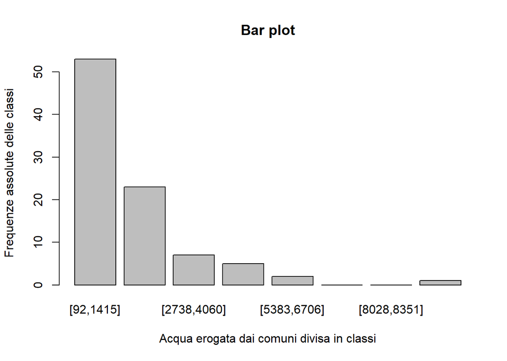

```r
#grafico a barre per classi
barplot(freq_ass_class,
        main = 'Bar plot',
        xlab = 'Acqua erogata dai comuni divisa in classi',
        ylab = 'Frequenze assolute delle classi')
```

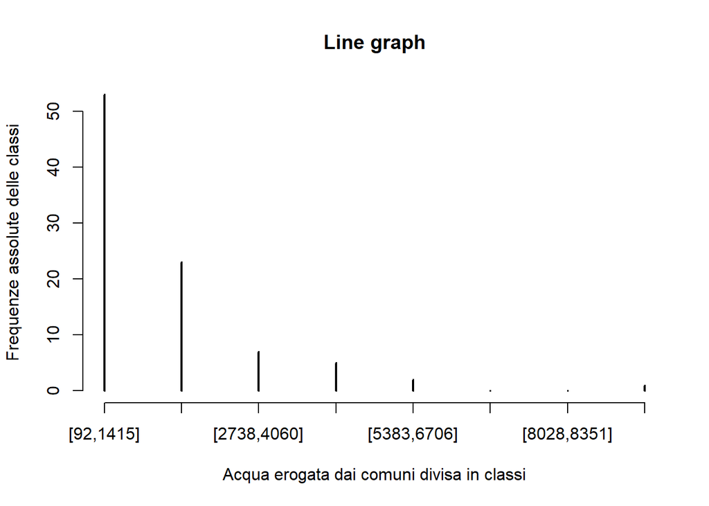

```r
#grafico ad aste per classi
plot(freq_ass_class,
     main = 'Line graph',
     xlab = 'Acqua erogata dai comuni divisa in classi',
     ylab = 'Frequenze assolute delle classi')
```

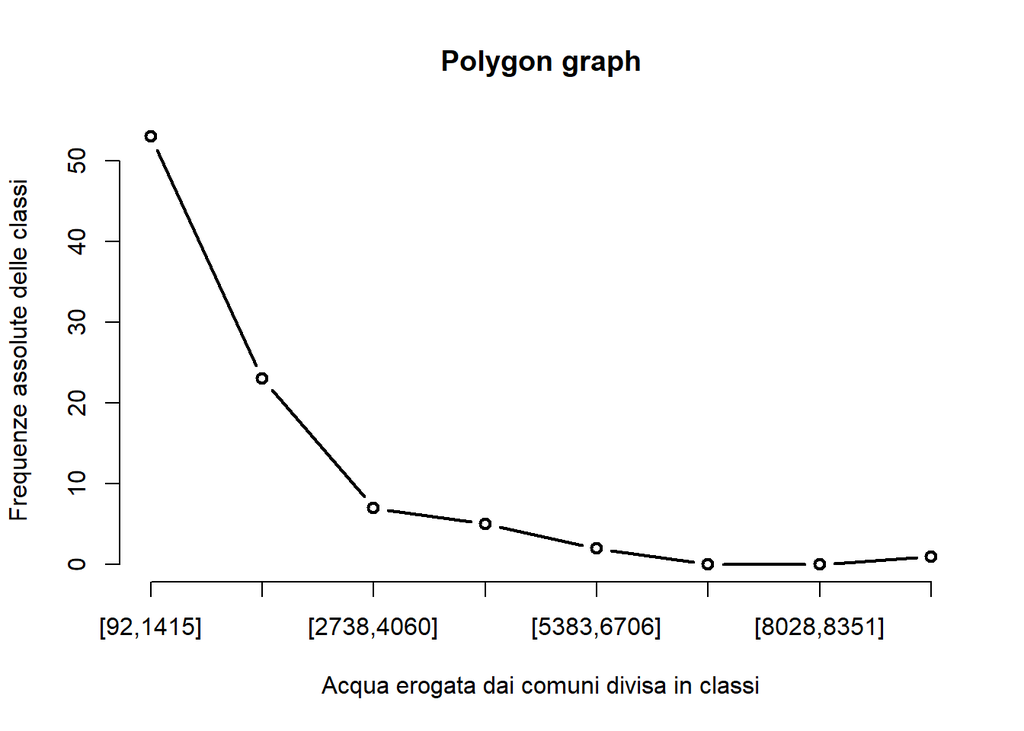

```r
#grafico a linee per classi
plot(freq_ass_class,
     main = "Polygon graph",
     type = "b",
     xlab = "Acqua erogata dai comuni divisa in classi",
     ylab = "Frequenze assolute delle classi")
```

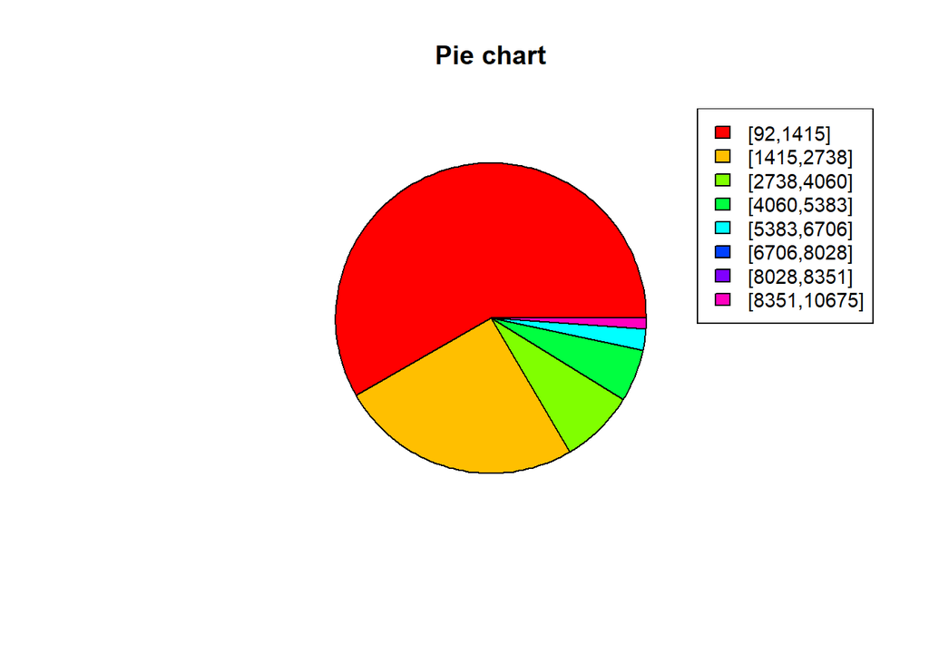

```r
#grafico a torta per classi


pie(freq_ass_class,
    main = 'Pie chart',
    col = rainbow(length(freq_ass_class)),
    labels = "")

legend('topright', cex = 0.9, legend = z, fill = rainbow(length(freq_ass_class)))
```

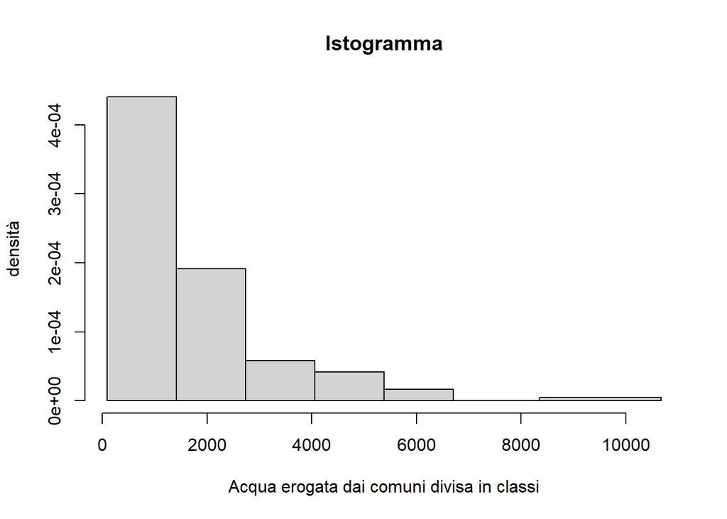

```r
#istogramma per classi
hist(finale$ACQ_EROG, main = 'Istogramma',xlab = 'Acqua erogata dai comuni divisa in classi',
     ylab = 'densità', breaks = x)
```

Per la divisione in classi abbiamo utilizzato un numero di livelli(K) pari a 8.

Abbiamo calcolato una costante(delta) che indica il range di una classe.

Grazie a questa costante, siamo riusciti a calcolare gli estremi degli 8 intervalli(Intervalli).

Abbiamo diviso la tabella in classi(tab_classi) e calcolato le sue frequenze(freq_ass_class, freq_rel_class, freq_ass_cum_class, freq_rel_cum_class).

Infine, abbiamo realizzato i grafici corrispondenti alle frequenze assolute della tabella delle classi.

L’istogramma è stato realizzato per visualizzare l’andamento della distribuzione delle acque erogate dai comuni.

Dunque, si può dedurre da tutti i grafici rappresentati che abbiamo molti comuni con un valore basso di acque erogate da esso e pochi che hanno un valore alto di acque erogate dovuto soprattutto dalla grandezza del comune e dalla quantità di acqua che serve ai cittadini.

# Quartili, scarto interquartile e boxplot

```r
#primo quartile
q1 <- quantile(finale$ACQ_EROG, probs=0.25)
q1
```

```
## 25%
## 531
```

```r
#secondo quartile o mediana
q2 <- quantile(finale$ACQ_EROG, probs=0.5)
q2
```

```
##  50%
## 1022
```

```r
#terzo quartile
q3 <- quantile(finale$ACQ_EROG, probs=0.75)
q3
```

```
##  75%
## 2054
```

```r
#scarto interquartile
iqr <- q3-q1
iqr <- substr(iqr,1,9)
iqr
```

```
## [1] "1523"
```

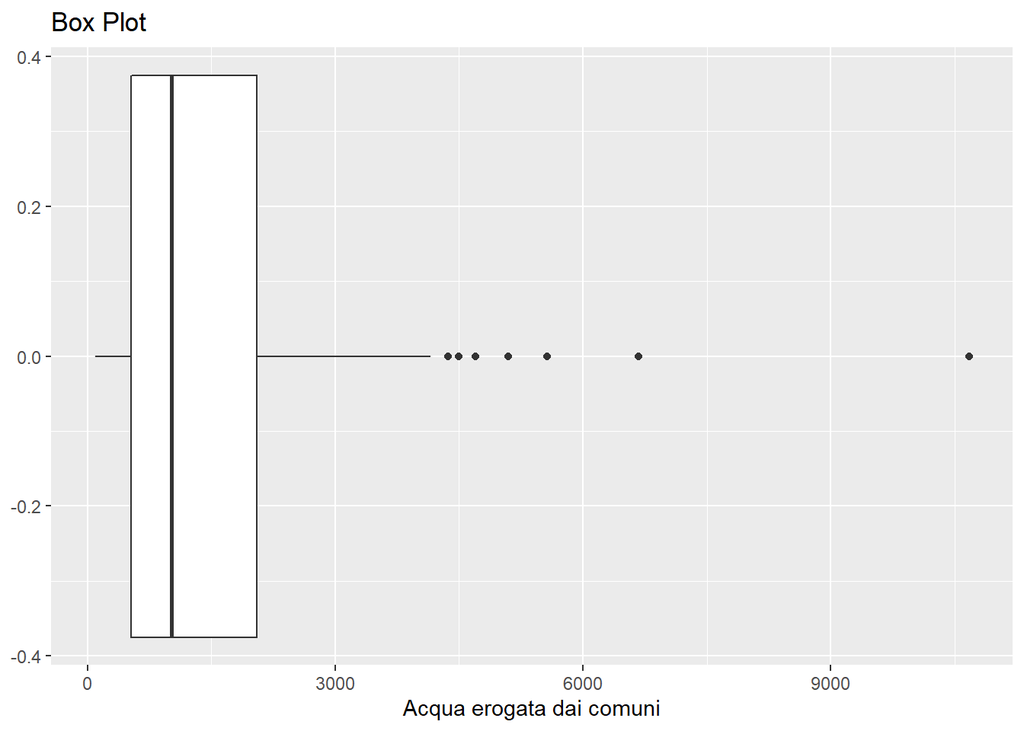

```r
ggplot(data = finale, mapping = aes(x=ACQ_EROG))+geom_boxplot()+
   labs(title = 'Box Plot', x = 'Acqua erogata dai comuni')
```

il percentile k-esimo di un campione di dati è un valore maggiore di una percentuale k dei dati, e minore della restante percentuale 100-k, dove k è un numero compreso tra 0 e 100. Il 25-esimo percentile si definisce primo quartile, il 50-esimo percentile si definisce mediana campionaria o secondo quartile, il 75-esimo percentile si dice terzo quartile e si denotano con Q1, Q2 e Q3. Nel nostro caso Q1 vale 531(q1), Q2 vale 1022(q2, come la mediana) e Q3 vale 2054(q3).

Uno strumento grafico utile a visualizzare alcuni degli indici rappresentativi dei dati è il box plot. Si ottiene sovrapponendo ad una linea orizzontale che va dal minore al maggiore dei dati, un rettangolo che va dal primo al terzo quartile, con una linea verticale che lo divide al livello del secondo quartile.

Lo scarto interquartile è la differenza tra Q3 e Q1 e indica la lunghezza della base del rettangolo. Nel nostro caso lo scarto interquartile vale 1523.

Il fatto che la mediana rappresentata nel boxplot sia più spostata verso sinistra, conferma che la distribuzione è asimmetrica positiva. Ciò poteva essere notato anche nell’istrogramma realizzato in precedenza.

# Intervalli di previsione con k=1,2,3

```r
#intervallo per k=1
int1_x<-mean-sd
int1_y<-mean+sd
int1_x
```

```
## [1] -67.90978
```

```r
int1_y
```

```
## [1] 3307.294
```

```r
#intervallo per k=2
int2_x<-mean-(2*sd)
int2_y<-mean+(2*sd)
int2_x
```

```
## [1] -1755.512
```

```r
int2_y
```

```
## [1] 4994.896
```

```r
#intervallo per k=3
int3_x<-mean-(3*sd)
int3_y<-mean+(3*sd)
int3_x
```

```
## [1] -3443.114
```

```r
int3_y
```

```
## [1] 6682.499
```

Gli intervalli di previsione ci permettono di capire se il nostro campione di dati ha una distribuzione normale cioé normocurtica. Per essere tale il primo intervallo deve avere circa il 68% dei dati, il secondo intervallo deve avere circa il 95% dei dati e il terzo intervallo deve avere circa il 99.7% dei dati.

Gli intervalli di previsione sono: [-67.90978, 3307.294] per k=1, in questo intervallo ci sono il 86.81% degli elementi totali [-1755.512, 4994.896] per k=2, in questo intervallo ci sono il 95.6% degli elementi totali [-3443.114, 6682.499] per k=3, in questo intervallo ci sono il 98.9% degli elementi totali. Possiamo notare, quindi, che il nostro campione di dati è fortemente sbilanciato e si dice skewed (ossia asimmetrico).

# Dati bivariati e coefficiente di correlazione campionario

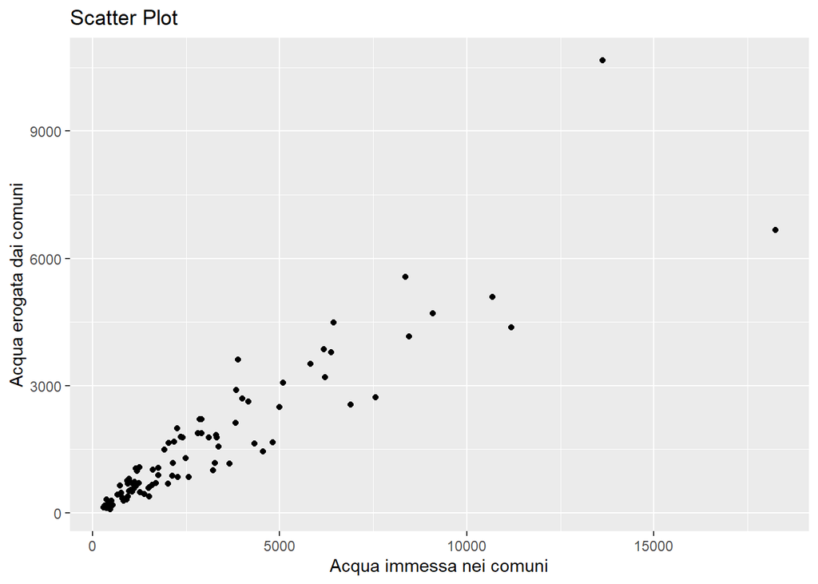

```r
#diagramma a dispersione, con x_i=ACQ_IMM e y_i = ACQ_EROG
ggplot(data = finale, mapping = aes(x=ACQ_IMM,y=ACQ_EROG))+geom_point()+
   labs(title = 'Scatter Plot', y = 'Acqua erogata dai comuni', x = 'Acqua immessa nei comuni')
```

```r
#coefficiente di correlazione campionario
r<-cor(finale$ACQ_EROG,finale$ACQ_IMM)
r
```

```
## [1] 0.9153466
```

Un campione bivariato è un campione che non tratta dati singoli ma coppie di dati. Uno strumento utile a visualizzare campioni bivariati è il diagramma a dispersione(Scatter Plot), che consiste nella rappresentazione sul piano cartesiano di tanti punti quante sono le osservazioni (xi, yi), ognuno tracciato nella corrispondente coordinata.

Un valore che permette di capire se i dati sono correlati positivamente o negativamente è il coefficiente di correlazione campionario(r), che nel nostro caso vale 0.9153466 ed è un valore prossimo a 1.

Se r>0 allora i dati sono positivamente correlati altrimenti sono negativamente correlati, quindi i dati sono positivamente correlati.

Realizzato da: D’Antuono Francesco Paolo (0512109798), Vitale Ciro (0512110719).